# gis-ws-10-1

CoWeber, aschupp, santowsa

30 Januar 2018

# Tuning Tree segmentation with FUSION

The Fusion TreeSeg system function allowed only a few parameter settings for the watershed segmentation algorithm. If we want to tune the algorithm, we have to change the input data to improve the model: First we changed the dtm cell-size to 1,2,3,4,5 and 10 meters.We used a focal window (3x3m) to filer the CHM and heightbreak (n-th percentile tif). We tried differend percentiles as the min. heightbreaks for the TreeSeg function.

### Workflow:

- 1. Iterate over variable a different cell-sizes for TreeSeg
- 2. As shown in gis-ws-09-1 create CHM, Heightbreak and blend it to basin maps and .shp-files

### Code (TreeSeg-function)

```r
### data input:
maindir="E:/gis-ws-10-1/"
indir="input/"
outdir="output/"
results="results/"
Fusion<-"E:/gIs/FUSION/"
library(sp)
library(raster)
library(rgdal)

### variables:
a=c(1,2,3,4,5,10) # extent of dtm-cell-size
c=c(35, 36, 37) # colname in csv2frid --> n-th percentil (37 = 95th percentile)
laslist=list.files(paste0(maindir,indir),pattern=".las$", full.names=FALSE)
#if extension is known use switch "/gridxy" in CanopyModel.exe

### TreeSeg-function:
TreeSeg=function(laslist,a,c){
  for (i in laslist){
    system(paste0(Fusion,"catalog.exe ",maindir,indir,i," ",
                  maindir,outdir,i,".html"))
    extent<-read.csv(paste0(maindir,outdir,i,".csv"))
    system(paste0(paste0(Fusion,"clipdata.exe"," /class:2 ",
                         maindir,indir,i," ",
                         maindir,outdir,i,"_groundpts.las "),
                  paste(extent$MinX,extent$MinY,extent$MaxX,extent$MaxY)))
    for (j in a){
      system(paste0(Fusion,"gridsurfacecreate.exe ",
                    maindir,outdir,i,"_",j,"m_gridsurf.dtm "
                    ,j," M M 1 32 0 0 ",maindir, outdir,i,"_groundpts.las"))
      system(paste0(Fusion, "CanopyModel.exe ","/ground:",maindir,outdir,i,"_",j,"m_gridsurf.dtm
                    ",
                    "/smooth:3 ","/peaks ",
                    ### smooth: mean filter for CanopyModel with 3x3 extent and peaks: show                         ### local maxima in canopy height model
                    maindir,results,i,"_",j,"m_CHM.dtm ",j," M M 1 32 0 0 ",maindir,indir,i))
      system(paste0(Fusion,"DTM2ASCII.exe ",maindir,results,i,"_",j,"m_CHM.dtm
                    ",maindir,results,i,"_",
                    j,"m_CHM.asc"))
      tempo=raster(paste0(maindir,results,i,"_",j, "m_CHM.asc"))
      projection(tempo) <- CRS("+init=epsg:25832")
      writeRaster(tempo,paste0(maindir,results,i,"_",j,"m_CHM."),format="GTiff")
      system(paste0(Fusion,"gridmetrics.exe ",maindir,outdir,i,"_",j,"m_gridsurf.dtm ",0," " ,
                    1," ",maindir,results,i,"_",j,"m_stattab.csv ",maindir,indir,i))
      for (l in c){
        system(paste0(Fusion,"csv2grid.exe ",maindir,results,i,"_",j,
                      "m_stattab_all_returns_intensity_stats.csv ",l,"
                      ",maindir,results,i,"_",j,"m_",l,
                      "perc.asc"))
        tempo=raster(paste0(maindir,results,i,"_",j,"m_",l, "perc.asc"))
        #ex=extent(c(477248, 477468, 5631722,5631891))
        #tempo <- crop(tempo,ex)
        projection(tempo) <- CRS("+init=epsg:25832")
        tempo=focal(tempo,w=matrix(1,3,3),fun=mean)
        writeRaster(tempo,paste0(maindir,results,i,"_",j,"m_",l,"perc."),format="GTiff")
        system(paste0(Fusion, "TreeSeg.exe ","/shape ",
                      maindir,results,i,"_",j,"m_CHM.dtm
                      ",maindir,results,i,"_",j,"m_",l,"perc.tif ",
                      maindir,results,i,"_",j, "_treeseg_",l,"perc.csv "))
        tempo=raster(paste0(maindir,results,i,"_",j,"_treeseg_",l,"perc", "_Basin_Map.asc"))
        projection(tempo) <- CRS("+init=epsg:25832")
        writeRaster(tempo,paste0(maindir,results,i,"_",j,"_",l,"_Basin_Map."),format="GTiff")
        shapes <- readOGR(paste0(maindir,results,i,"_",j,"_treeseg_",l,"perc","_Polygons.shp"))
        projection(shapes) <- CRS("+init=epsg:25832")
        writeOGR(shapes,dsn=paste0(maindir,results,i,"_",j,"m_",l,"perc","_Polygons_class",
                                   ".shp"),
                 driver = "ESRI Shapefile",layer="treesize")
        shapes <- readOGR(paste0(maindir,results,i,"_",j,"_treeseg_",l,"perc","_HighPoints.shp")
                          )
        projection(shapes) <- CRS("+init=epsg:25832")
        writeOGR(shapes,dsn=paste0(maindir,results,i,"_",j,"m_",l,"perc","_HighPoints_class",
                                   ".shp"),
                 driver = "ESRI Shapefile",layer="treepoint")
      }
    }
  }
}

TreeSeg(laslist = i1,a=a,c=c)
```

### Results:

In the area mapped by Jannis our result with 2x2 cell-size (dtm) and heigthbreak (95th percentile) shows the following 26 trees:

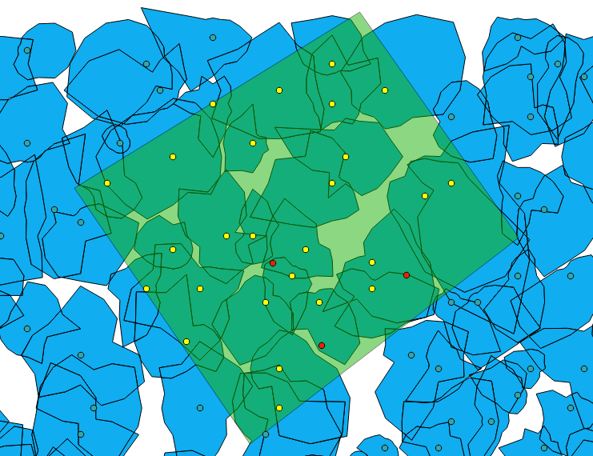

TreeSeg (2x2_95thpercentile)

For comparison the 1x1 cell-size (dtm) and heightbreak (95th percentile shows 111 trees):

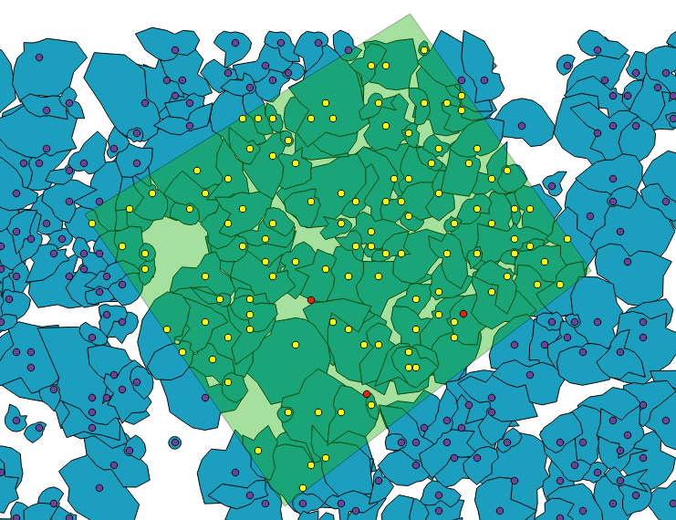

TreeSeg (1x1_95thpercentile)

By the fact that the mapped area should have between 30 and 60 trees, the 2x2m cell-size TreeSeg shows a nearly comparabel result.